# Bivariate Analysis

Christian Hicks

Last compiled on 01 November 2021

## Working Hours

### Unweighted

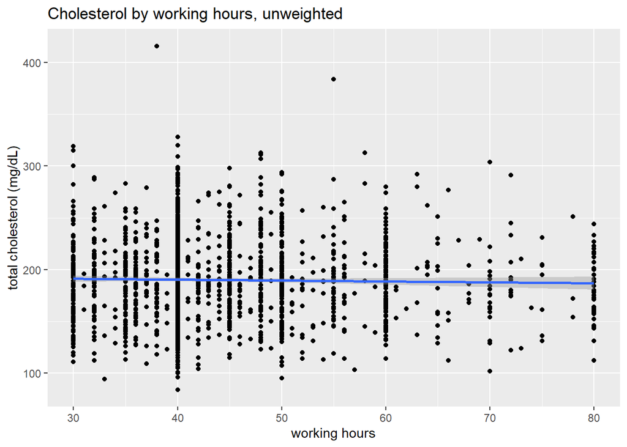

| term | estimate | std.error | statistic | p.value | conf.low | conf.high |
| --- | --- | --- | --- | --- | --- | --- |
| (Intercept) | 193.791 | 3.851 | 50.319 | 0.000 | 186.243 | 201.339 |
| Working hours | -0.087 | 0.085 | -1.021 | 0.307 | -0.253 | 0.080 |

Correlation: -0.023

### Weighted

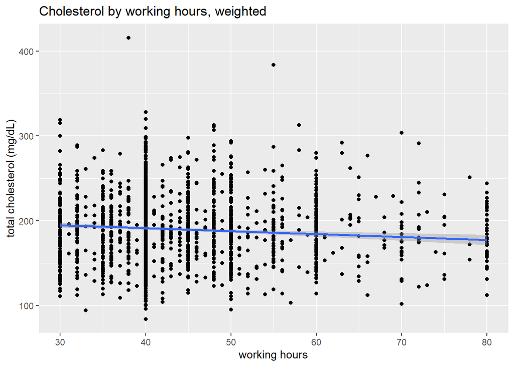

| term | estimate | std.error | statistic | p.value | conf.low | conf.high |
| --- | --- | --- | --- | --- | --- | --- |
| (Intercept) | 205.073 | 5.327 | 38.499 | 0.000 | 194.626 | 215.519 |
| Working hours | -0.347 | 0.115 | -3.006 | 0.003 | -0.573 | -0.120 |

Correlation: -0.0935

## Age

### Unweighted

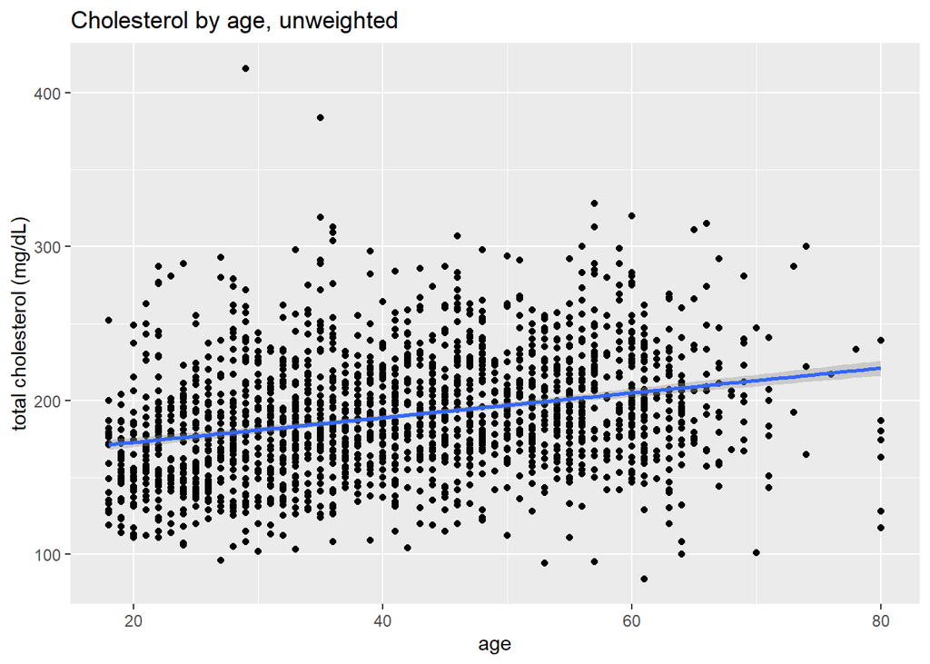

| term | estimate | std.error | statistic | p.value | conf.low | conf.high |
| --- | --- | --- | --- | --- | --- | --- |
| (Intercept) | 156.638 | 2.664 | 58.797 | 0.00e+00 | 151.416 | 161.859 |
| Age | 0.805 | 0.061 | 13.178 | 4.59e-38 | 0.686 | 0.925 |

Correlation: 0.285

### Weighted

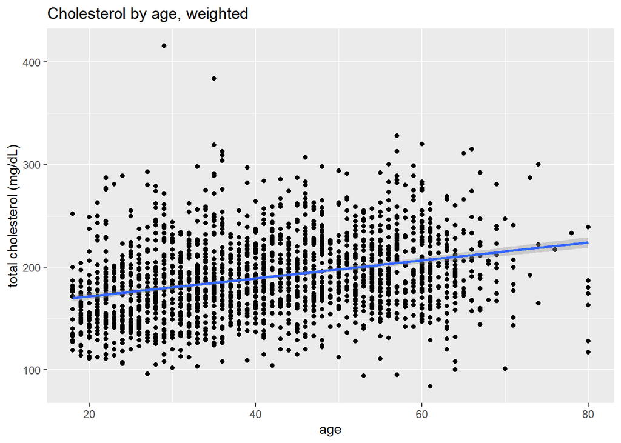

| term | estimate | std.error | statistic | p.value | conf.low | conf.high |
| --- | --- | --- | --- | --- | --- | --- |
| (Intercept) | 154.108 | 3.987 | 38.648 | 1.18e-243 | 146.288 | 161.928 |
| Age | 0.875 | 0.098 | 8.881 | 1.45e-18 | 0.682 | 1.068 |

Correlation: 0.295

## Gender

### Unweighted

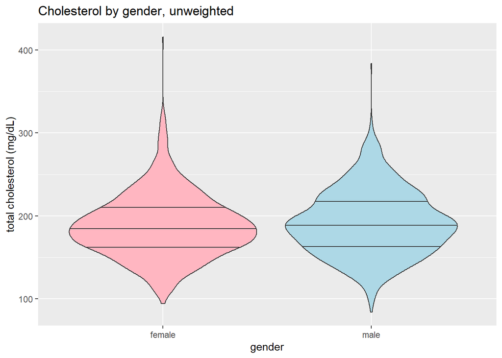

| term | estimate | std.error | statistic | p.value | conf.low | conf.high |
| --- | --- | --- | --- | --- | --- | --- |
| (Intercept) | 188.045 | 1.278 | 147.105 | 0.0000 | 185.539 | 190.550 |
| Male | 3.594 | 1.751 | 2.053 | 0.0402 | 0.163 | 7.025 |

T test:

| estimate | estimate1 | estimate2 | statistic | p.value | parameter | conf.low | conf.high | method | alternative |
| --- | --- | --- | --- | --- | --- | --- | --- | --- | --- |
| -3.593874 | 188.0446 | 191.6384 | -2.055593 | 0.0399551 | 1943.623 | -7.022692 | -0.1650568 | Welch Two Sample t-test | two.sided |

Female mean (SD): 188.04 (38.38)

Male mean (SD): 191.64 (39.12)

### Weighted

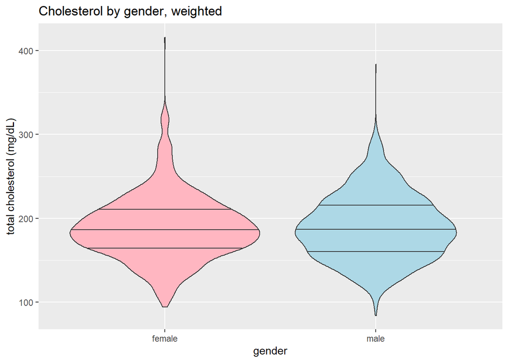

| term | estimate | std.error | statistic | p.value | conf.low | conf.high |
| --- | --- | --- | --- | --- | --- | --- |
| (Intercept) | 189.292 | 1.895 | 99.877 | 0.000 | 185.575 | 193.009 |
| Male | 0.374 | 2.582 | 0.145 | 0.885 | -4.691 | 5.438 |

T test:

| estimate | statistic | p.value | parameter | conf.low | conf.high | method | alternative |
| --- | --- | --- | --- | --- | --- | --- | --- |
| 0.373526 | 0.1446501 | 0.885002 | 1969 | -4.690749 | 5.437801 | Design-based t-test | two.sided |

Female mean (SD): 189.29 (38.65)

Male mean (SD): 189.67 (38.703)

## Doctor Opinion

### Unweighted

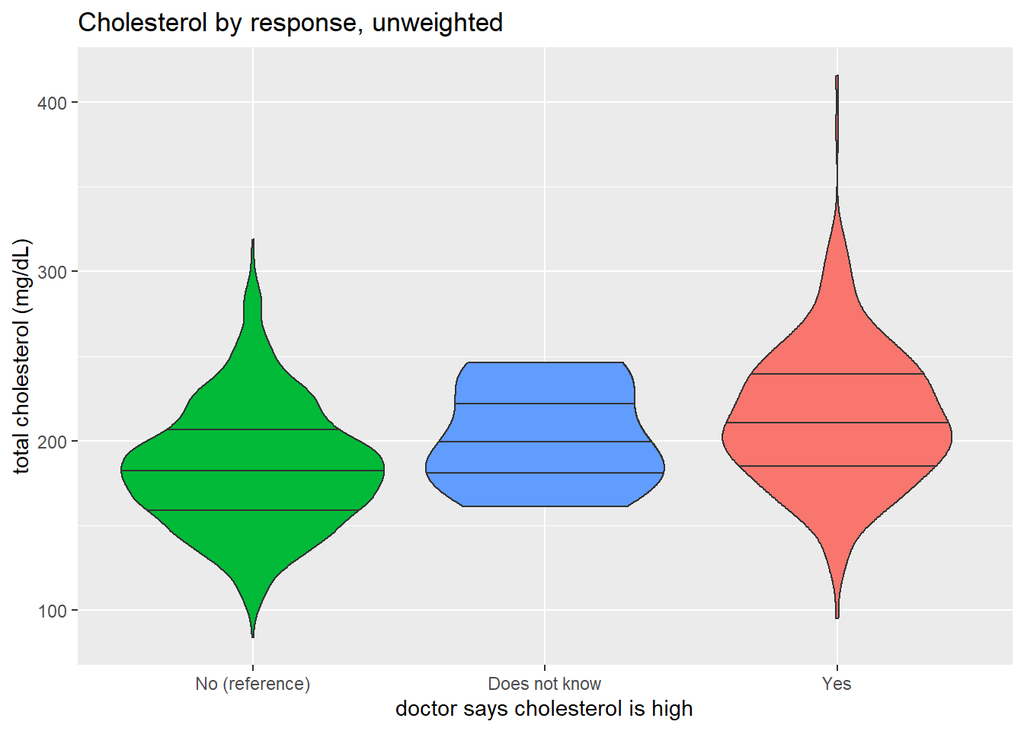

| term | estimate | std.error | statistic | p.value |
| --- | --- | --- | --- | --- |
| (Intercept) | 184.495 | 0.926 | 199.280 | 0.000 |
| Yes | 29.647 | 2.165 | 13.691 | 0.000 |
| Does not know | 18.505 | 14.049 | 1.317 | 0.188 |

ANOVA:

| term | df | sumsq | meansq | statistic | p.value |
| --- | --- | --- | --- | --- | --- |
| chol_doctor_hi | 2 | 259053 | 129526.511 | 94.15423 | 0 |
| Residuals | 1968 | 2707347 | 1375.684 | NA | NA |

Pairwise:

| group1 | group2 | p.value |
| --- | --- | --- |
| No | Yes | 0.0000000 |
| Does not know | Yes | 1.0000000 |
| Does not know | No | 0.5638532 |

No mean (SD): 184.495 (36.103)

Don’t know mean (SD): 203 (32.29)

Yes mean (SD): 214.14 (41.29)

### Weighted

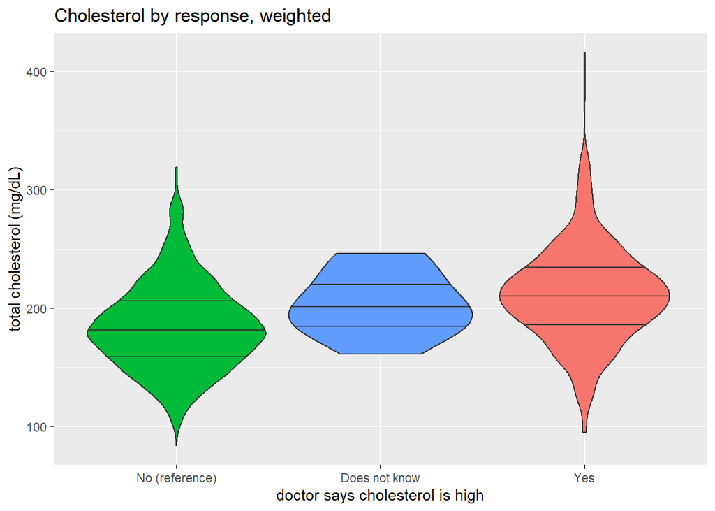

| term | estimate | std.error | statistic | p.value |
| --- | --- | --- | --- | --- |
| (Intercept) | 184.373 | 1.345 | 137.087 | 0.0000 |
| Yes | 27.145 | 3.498 | 7.761 | 0.0000 |
| Does not know | 19.948 | 9.235 | 2.160 | 0.0309 |

ANOVA:

| term | df | sumsq | meansq | statistic | p.value |
| --- | --- | --- | --- | --- | --- |
| chol_doctor_hi | 2 | 12026473350 | 6013236675 | 80.21184 | 0 |
| Residuals | 1968 | 147534945371 | 74966944 | NA | NA |

(p value = 3.25e-34)

Pairwise:

| group1 | group2 | p.value |
| --- | --- | --- |
| No | Yes | 0.0000000 |
| Does not know | Yes | 1.0000000 |
| Does not know | No | 0.5638532 |

(1st p value = 2.41e-40)

Yes mean (SD): 211.52 (41.016)

No mean (SD): 184.373 (36.278)

Don’t know mean (SD): 204.3 (26.913)

## Sitting minutes

### Unweighted

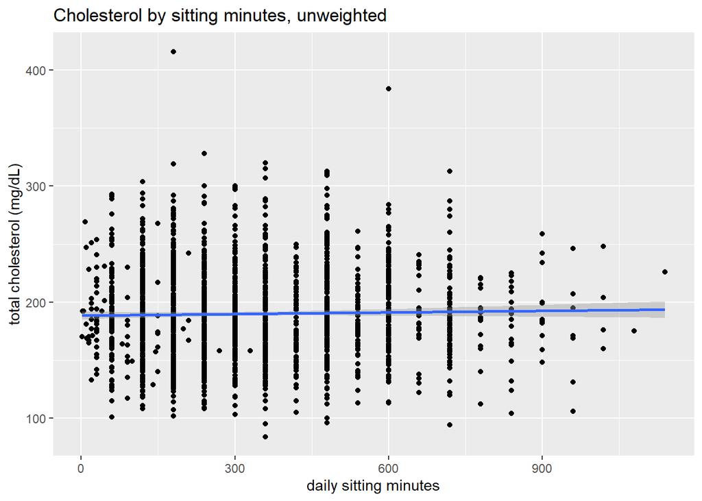

| term | estimate | std.error | statistic | p.value | conf.low | conf.high |
| --- | --- | --- | --- | --- | --- | --- |
| (Intercept) | 188.441 | 1.658 | 113.653 | 0.000 | 185.192 | 191.691 |
| Sitting minutes | 0.004 | 0.004 | 1.045 | 0.296 | -0.004 | 0.013 |

Correlation: 0.0236

### Weighted

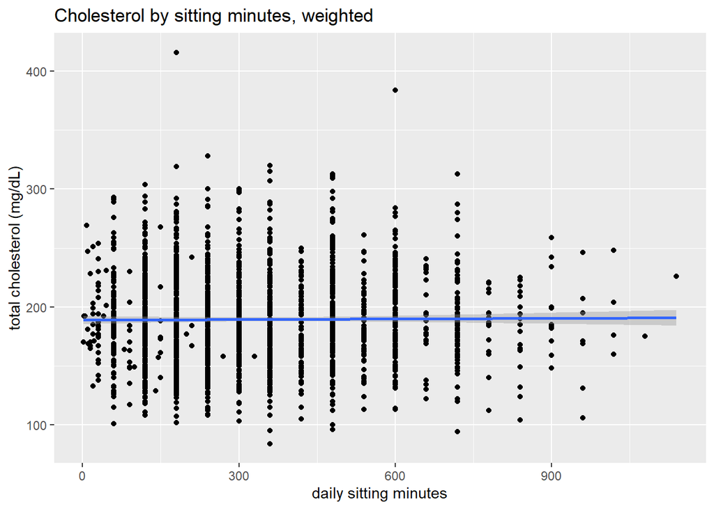

| term | estimate | std.error | statistic | p.value | conf.low | conf.high |
| --- | --- | --- | --- | --- | --- | --- |
| (Intercept) | 188.887 | 2.565 | 73.641 | 0.000 | 183.857 | 193.918 |
| Sitting minutes | 0.002 | 0.006 | 0.274 | 0.784 | -0.010 | 0.014 |

Correlation: 0.00912

## Vigorous work activity

### Weighted

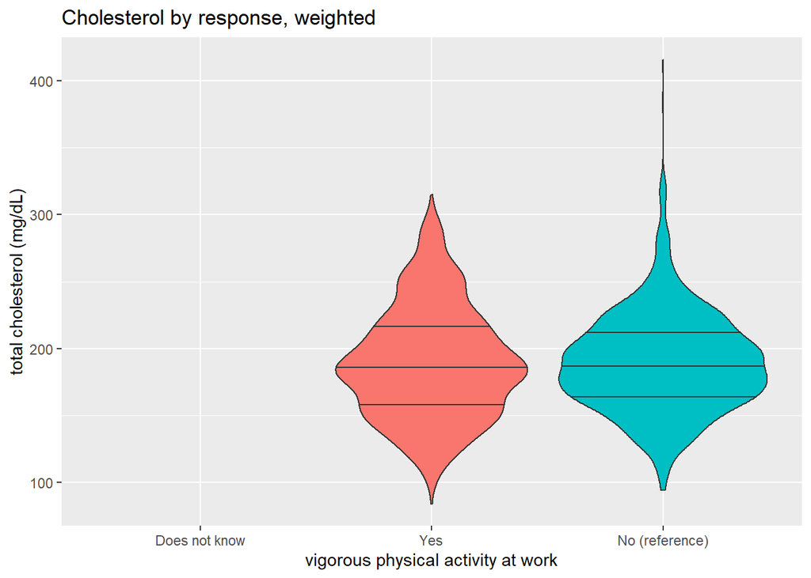

| term | estimate | std.error | statistic | p.value |
| --- | --- | --- | --- | --- |
| (Intercept) | 189.5470234 | 1.517139 | 124.9371589 | 0.0000000 |
| Yes | -0.1059614 | 2.812322 | -0.0376775 | 0.9699486 |
| Does not know | -34.5470234 | 1.517139 | -22.7711672 | 0.0000000 |

ANOVA:

| term | df | sumsq | meansq | statistic | p.value |
| --- | --- | --- | --- | --- | --- |
| phys_work_vig | 2 | 33886801 | 16943400 | 0.209021 | 0.8113962 |
| Residuals | 1968 | 159527531920 | 81060738 | NA | NA |

Yes mean (SD): 189.44 (41.48)

No mean (SD): 189.55 (37.09)

Don’t know mean (SD): 155 (NaN) (1 obs)

## Vigorous recreational activity

### Weighted

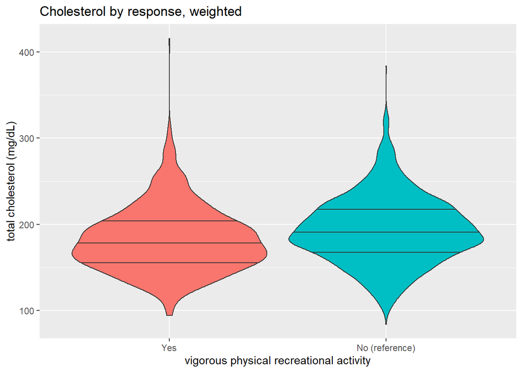

| term | estimate | std.error | statistic | p.value |
| --- | --- | --- | --- | --- |
| (Intercept) | 193.55163 | 1.644036 | 117.729555 | 0.00e+00 |
| Yes | -11.18033 | 2.542686 | -4.397056 | 1.16e-05 |

T test:

| estimate | statistic | p.value | parameter | conf.low | conf.high | method | alternative |
| --- | --- | --- | --- | --- | --- | --- | --- |
| 11.18033 | 4.397056 | 1.16e-05 | 1969 | 6.193695 | 16.16697 | Design-based t-test | two.sided |

Yes mean (SD): 182.37 (37.56)

No mean (SD): 193.55 (38.73)

## Race/Ethnicity

### Weighted

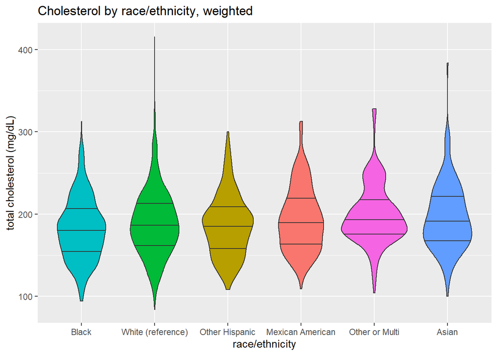

| term | estimate | std.error | statistic | p.value |
| --- | --- | --- | --- | --- |
| (Intercept) | 189.018138 | 1.939254 | 97.4695067 | 0.0000000 |
| Mexican American | 5.082796 | 3.248215 | 1.5647969 | 0.1177916 |
| Other Hispanic | -2.701855 | 3.619938 | -0.7463816 | 0.4555262 |
| Non-Hispanic Black | -6.985472 | 2.757409 | -2.5333463 | 0.0113751 |
| Non-Hispanic Asian | 7.651363 | 3.198348 | 2.3922860 | 0.0168372 |
| Other race or Multi-Racial | 10.709981 | 5.555263 | 1.9278982 | 0.0540117 |

ANOVA:

| term | df | sumsq | meansq | statistic | p.value |
| --- | --- | --- | --- | --- | --- |
| race_eth | 5 | 1764961767 | 352992353 | 4.395726 | 0.0005534 |
| Residuals | 1965 | 157796456953 | 80303540 | NA | NA |

Pairwise:

| group1 | group2 | p.value |
| --- | --- | --- |
| 2 | 1 | 1.0000000 |
| 3 | 1 | 0.1848452 |
| 3 | 2 | 1.0000000 |
| 4 | 1 | 0.0068440 |
| 4 | 2 | 1.0000000 |
| 4 | 3 | 1.0000000 |
| 6 | 1 | 1.0000000 |
| 6 | 2 | 0.1704348 |
| 6 | 3 | 0.0020858 |
| 6 | 4 | 0.0000311 |
| 7 | 1 | 1.0000000 |
| 7 | 2 | 1.0000000 |
| 7 | 3 | 0.5851186 |
| 7 | 4 | 0.0900986 |
| 7 | 6 | 1.0000000 |

Mexican American mean (SD): 194.101 (38.78)

Other Hispanic mean (SD): 186.32 (37.08)

Non-Hispanic White mean (SD): 189.02 (38.78)

Non-Hispanic Black mean (SD): 182.03 (37.401)

Non-Hispanic Asian mean (SD): 196.67 (40.35)

Other race or Multi-Racial mean (SD): 199.73 (36.46)

## Education

### Weighted

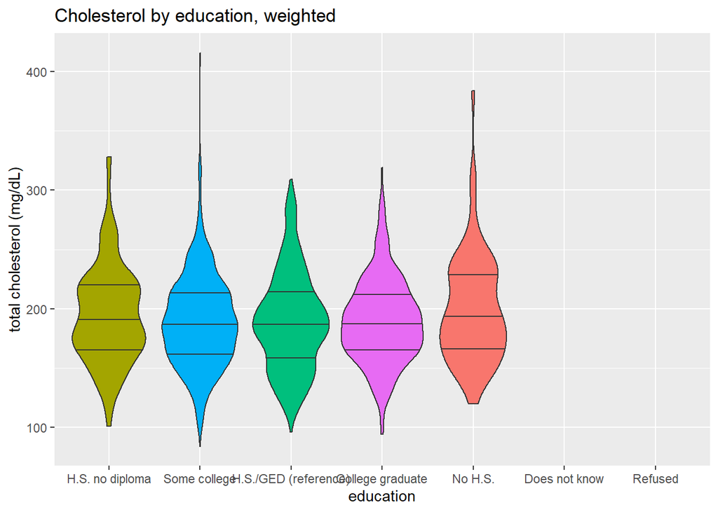

[output not shown]

ANOVA:

| term | df | sumsq | meansq | statistic | p.value |
| --- | --- | --- | --- | --- | --- |
| education | 6 | 681907588 | 113651265 | 1.397945 | 0.2116931 |
| Residuals | 1909 | 155199429099 | 81298810 | NA | NA |

No H.S. mean (SD): 199.61 (45.89)

H.S. no diploma mean (SD): 194.98 (41.13)

H.S. or GED mean (SD): 189.21 (40.99)

Some college mean (SD): 189.26 (38.195)

College graduate mean (SD): 189.97 (35.59)

Refused mean (SD): 298 (NaN) (1 obs)

Don’t know mean (SD): 192 (NaN) (1 obs)

## Povery ratio

### Weighted

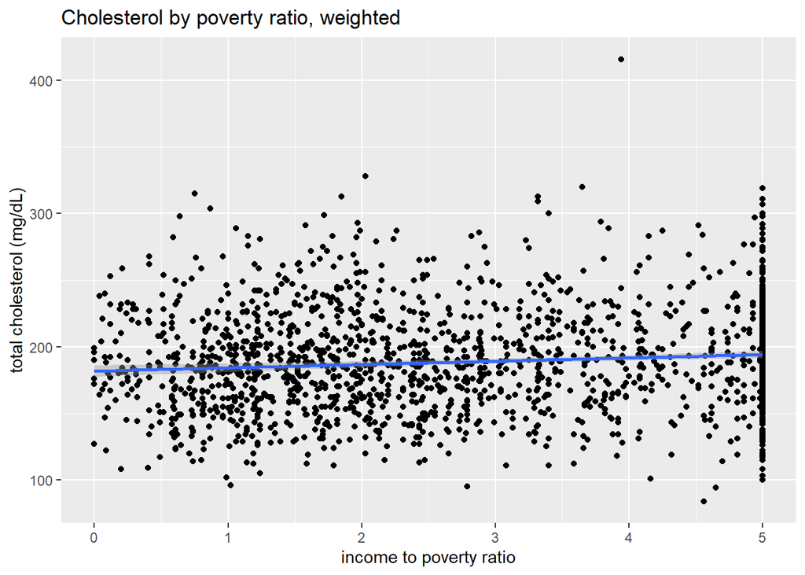

| term | estimate | std.error | statistic | p.value | conf.low | conf.high |
| --- | --- | --- | --- | --- | --- | --- |
| (Intercept) | 181.767075 | 2.5883169 | 70.22598 | 0.00000 | 176.6905006 | 186.843649 |
| Income to poverty ratio | 2.474462 | 0.8244495 | 3.00135 | 0.00273 | 0.8574346 | 4.091489 |

Correlation: 0.1004